# Jupyter notebook example title - Course Template

[output not shown]

The only way to add "metadata" to a jupyter notebook is to modify the notebook [metadata itself](https://github.com/microsoft/vscode-jupyter/issues/1182). However, this is still not caught by mkdocs, so there is no way to add metadata to the html file. Mkdocs material also cannot fetch the hide options from the yaml menu, which is a pity.

# Jupyter notebook example title

## Writing admonitions

You can write admonitions in html code. Unfortunately it has to be this way...

You need to write as the class inside the `<div>` tag "admonition {type}", e.g. "admonition note" or "admonition tip". Then in the following `<p>` block, you should add the class "admonition-title", followed by the title of the admonition. In the next `<p>` block, you can add the content.

Title of the admonition

Here is an example of a dropdown admonition. You do not need to provide the class in this case since it is wrapped inside the `<details>` tag, but you need to provide a suitable admonition type in class (e.g., "warning" or "note"). The title of the admonition is inside the `<summary>` tag.

**Title of drop-down**

Content

Inside the html

**Bold text** You will need `<strong>` and `</strong>` tags for bold text

*Italic text* You will need the `<i>` and `</i>` tags for italic text

Tab You will need the tag `&emsp;` to add a 4 space tab in html code

## Running code

This is some example code

```python
import pandas as pd
import numpy as np
import matplotlib.pyplot as plt


dataset_url = ('https://raw.githubusercontent.com/m-mehdi/pandas_tutorials/main/weekly_stocks.csv')
df = pd.read_csv(dataset_url, parse_dates=['Date'], index_col='Date')
pd.set_option('display.max.columns', None)
print(df.head())
```

```
                  MSFT          FB        AAPL
Date
2021-05-24  249.679993  328.730011  124.610001
2021-05-31  250.789993  330.350006  125.889999
2021-06-07  257.890015  331.260010  127.349998
2021-06-14  259.429993  329.660004  130.460007
2021-06-21  265.019989  341.369995  133.110001
```

```python
df.plot(y='MSFT', figsize=(9,6))
```

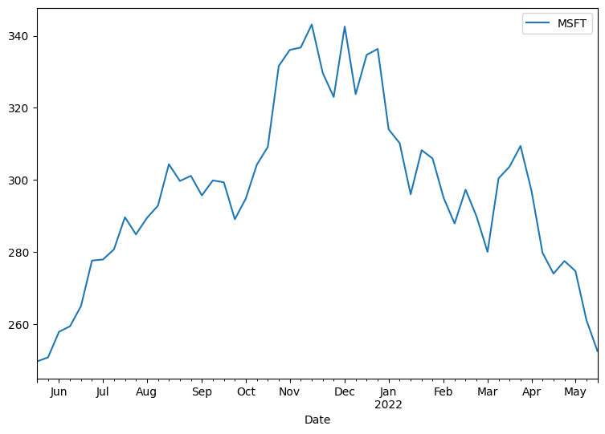